# Analyzing Government Food Support in New York

## **Project Report**

### Authors:

| Name | Email |
| --- | --- |
| Paul Kim | pkim3@uw.edu |
| Mason Howes | mhowes@uw.edu |
| Viru Repalle | virurep@uw.edu |
| Matthew Pedraja | mpedraj@uw.edu |

### **Date**: February 16th 2022

### **Code name**: *Yummy*

### **Affiliation**:

**INFO-201: Technical Foundations of Informatics - The Information School - University of Washington**

[figure not shown]

### **Abstract**:

We are concerned with changes to SNAP assistance given to individuals and families in need. This is a topic of concern because analyzing how the SNAP program has changed based on various relevant factors can help policy makers make more informed decisions on an important part of United States welfare to low-income parties. We plan to do this by analyzing a data set which has the amount of SNAP assistance given to families over time within the State of New York.

### **Keywords**:

*food insecurity, low income meals, SNAP access, government food support*

### **Introduction**:

Our group's project focuses on the change in number of persons who utilize SNAP within the different districts of the State of New York over the past 5 years to confirm whether or not the necessary parties are receiving the help that they need. We all believe that no one should have to worry about whether or not there will be food on the table each night, so SNAP, the Supplemental Nutrition Assistance Program, is something that each of us is passionate about for its success and ease of access. With this project, we hope to gain a better understanding of its impact on people's lives as well as to see whether or not the U.S. government is holding up their end on allowing residents of a selected State, being New York in this case, to have affordable food to feed their families. Finally, we aim for this information to be used by policymakers in order for them to make more informed decisions regarding food security in the United States.

### **Design Situation**:

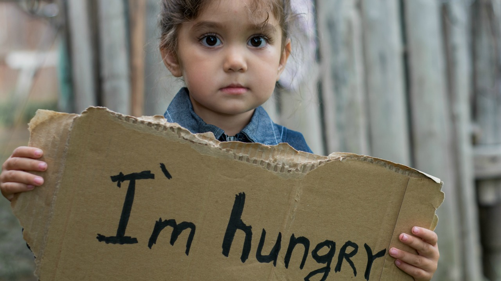

**Human Values**: Values associated and connected with our topic is maintaining the well-being of our community and the right to having access to food, making sure no one is deprived of that necessity, and raising awareness on the issues of hunger. These values originate from social and economical issues which have risen in the 21st century regarding the financial crises and COVID-19 pandemic, with over 10.5% of households having experienced food insecurity in the United States alone in 2019 ([Silva, 2020](https://www.npr.org/2020/09/27/912486921/food-insecurity-in-the-u-s-by-the-numbers.)). The issue of healthy foods in itself being expensive for an individual to sustain conflicts with the idea of providing food for everyone, which results in food insecurity ([Food and Agriculture Organization of the United Nations, 2021](https://www.fao.org/state-of-food-security-nutrition)).

**Stakeholders**: The direct stakeholders of our topic involves not only the citizens and residents of New York, but also other residents in different states that are experiencing food insecurity and are in need of SNAP benefits and other community based organizations, such as food banks and retail shops that provide food items for those who need it. The motivations and values the stakeholders contain is dealing and solving issues of hunger for everyone, and maintaining the well-being of the communities. Indirect stakeholders include politicians who cater to the people they are serving in order to maintain their status within the government through elections and provide assistance for struggling individuals. Indirect stakeholder may also include communities which may be impacted by future SNAP policy changes which may occur from this report.

**Benefits and Harms**: The potential benefits by exploring our topic involve raising support in favor of making sure everyone is able to have food, greatly benefiting every individual in need of food as well as every citizen by reducing the stress of food insecurity ([Keith-Jennings, 2019](https://www.cbpp.org/blog/raising-snap-benefits-would-have-powerful-effects-on-food-security-poverty-health)). However, potential harms could involve using the data provided as a means to push a political agenda and attack the political party associated, leading to a huge divide among the populace discouraging cooperation against solving hunger issues.

### **Research Questions**:

1. Which month(s) historically have the most Total SNAP benefits allocated to them?
2. How does the number of SNAP receiving households change throughout time? This can be categorized by NY as a whole or by individual districts as well
3. How did COVID-19 affect the number of SNAP benefits being distributed?
4. What is the trend for the total amount of SNAP assistance being given over time?

These questions can be answered through performing analysis on our dataset, which is described below. For example, we can answer question 1 by counting how many times a particular month was the highest receiver of SNAP benefits within each year. In order to count the months, we could need to perform filtering and grouping operations on the data.

### **The Dataset**:

**Size**: The dataset we chose has 14 columns and 13.9 thousand rows. Overall, it is a larger dataset because it has a lot of columns that are applied to thousands of rows.

**Complexity**: This is a complex dataset because it contains several features that apply to a significant amount of observations. The features go in depth in several different ways. One way is that the information is sorted by districts; this sorting offers a deeper perspective that is location based. Additionally, the data goes into higher detail by specifying if the SNAP data is temporary or non-temporary. If the data is temporary then it invokes the possibility of change in the future: a sign of growth and positive change. The aforementioned data is continued to be divided into three subsections each. They have data related to households, individual persons, and the total benefits. Households give a larger summary while the person's data is more detailed and individual-oriented. The benefits present a conglomeration of the prior sets and shows the impact of the food assistance program. Overall, the dataset is split up by months of the year. This organization provides for a structured way to view the data. It can be analyzed to see the difference made each month.

**Origins**: This dataset comes from the U.S. Government and it represents the number of people in the state of New York who are under the food assistance program. The observations are the number of people per month and distract who are in the specified columns provided. The data was collected by New York State Office of Temporary and Disability Assistance to asses the amount of food rationing that was being spent by the government. This data benefits the government because they are the ones who are spending the money on the food assistance. Therefore it would be useful to use this data to track their spending amounts. By tracking their spending, the government would be able to assess if they need to allocate more or less money in coming years, enabling them the view and predict patterns. If correctly used they can find ways to save resources on the program. The data is validated by New York City and Upstate Welfare Management Systems and it is published by the U.S. Government so it is reasonable to say this data is trustworthy. We obtained this data from the New York government data website.

#### **Analysis of Dataset**

**High-Level Summary Information**

For our project we calculated 5 pertinent values. The first was the district with the highest number of households and the second was the district with the lowest number of households. We found that *New York City* had the highest amount of households while *Hamilton* district has the lowest amount. These values are important because we can see the areas in an entire state that require the highest and lowest amount of support. In addition, we can compare these to the population of districts to see if there is a correlation between the two values. Then, we can create a proportion between the values to see what percent of the districts require support. This value can give a more detailed picture of what is happening. Then we extracted the year that year with the most cases and the amount of SNAP households in the year. The highest year was *2013* and it had a total of *20639634* households. These values show what years the government had to spend more money on food assistance programs and how many households they had to support. To further expand on this data, we found the temporary households in 2013 and gathered the proportion of temporary households: *0.3866259*. This data shows how many households in the highest year were only temporary support.

**Aggregated Data Table**

| District | Temporary Assistance SNAP Households Average | Non-Temporary Assistance SNAP Households Average |
| --- | --- | --- |
| Albany | 5674 | 9657 |
| Allegany | 1065 | 1721 |
| Broome | 5368 | 7884 |
| Cattaraugus | 1596 | 3427 |
| Cayuga | 1254 | 3036 |
| Chautauqua | 3694 | 7053 |
| Chemung | 2088 | 4255 |
| Chenango | 857 | 2272 |
| Clinton | 2062 | 3495 |
| Columbia | 1028 | 1709 |
| Cortland | 970 | 1975 |
| Delaware | 720 | 1664 |
| Dutchess | 3057 | 6276 |
| Erie | 23715 | 42626 |
| Essex | 621 | 1061 |
| Franklin | 1222 | 2012 |
| Fulton | 1173 | 2716 |
| Genesee | 781 | 1753 |
| Greene | 944 | 1580 |
| Hamilton | 41 | 159 |
| Herkimer | 1086 | 3114 |
| Jefferson | 2106 | 4620 |
| Lewis | 377 | 1100 |
| Livingston | 1015 | 2000 |
| Madison | 870 | 2469 |
| Monroe | 22070 | 29981 |
| Montgomery | 1176 | 2528 |
| Nassau | 12533 | 14913 |
| New York City | 420715 | 392815 |
| Niagara | 4755 | 8771 |
| Oneida | 6088 | 10381 |
| Onondaga | 10554 | 18714 |
| Ontario | 1472 | 2922 |
| Orange | 4766 | 9817 |
| Orleans | 846 | 1687 |
| Oswego | 2203 | 5254 |
| Otsego | 756 | 1806 |
| Putnam | 455 | 751 |
| Rensselaer | 2706 | 4538 |
| Rockland | 3122 | 8810 |
| Saratoga | 1619 | 4992 |
| Schenectady | 3506 | 6030 |
| Schoharie | 440 | 1163 |
| Schuyler | 306 | 704 |
| Seneca | 461 | 995 |
| St. Lawrence | 2467 | 4266 |
| Steuben | 1808 | 3212 |
| Suffolk | 16482 | 30436 |
| Sullivan | 1748 | 3256 |
| Tioga | 685 | 1732 |
| Tompkins | 1405 | 2524 |
| Ulster | 3116 | 5456 |
| Warren | 992 | 2202 |
| Washington | 906 | 2208 |
| Wayne | 1449 | 2965 |
| Westchester | 12849 | 21628 |
| Wyoming | 431 | 940 |
| Yates | 318 | 887 |

#### **Visualizations of Data**

**Which Months require the most SNAP benefit assistance?**

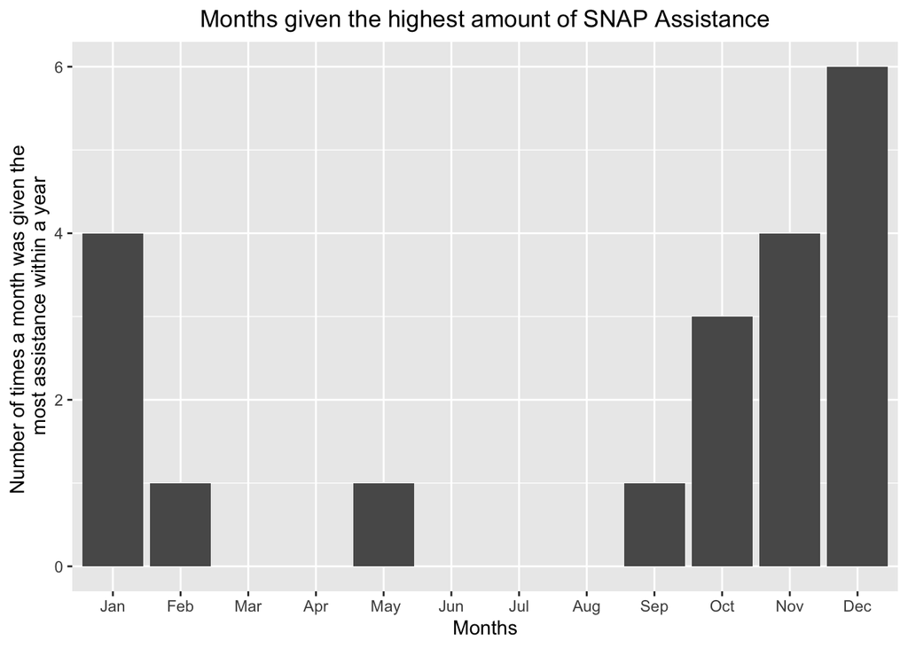

This chart showcases the amount of times a certain month within a year was allocated the most amount of SNAP assistance. Since our data set has the years range from 2002 to 2021, there are 20 years to choose the highest month. A column chart was used since we wanted an easy way to compare which months had the highest count. The column chart therefore totals up to a 20 y-axis count. This column chart is important as it can allow policy makers to see broad timings of when the SNAP program used the most amount of resources. This overview can allow them to better understand which timings for the program need the most amount of resources. This chart can also provide some insight as to why a certain time needs the most amount of SNAP assistance. For example, the winter months of Nov-Jan seem to be the months which generally use the greatest amount of SNAP assistance. This may be attributed to the increase of family mouths to feed in family gatherings for the holiday season.

**What is the trend of SNAP benefits over time?**

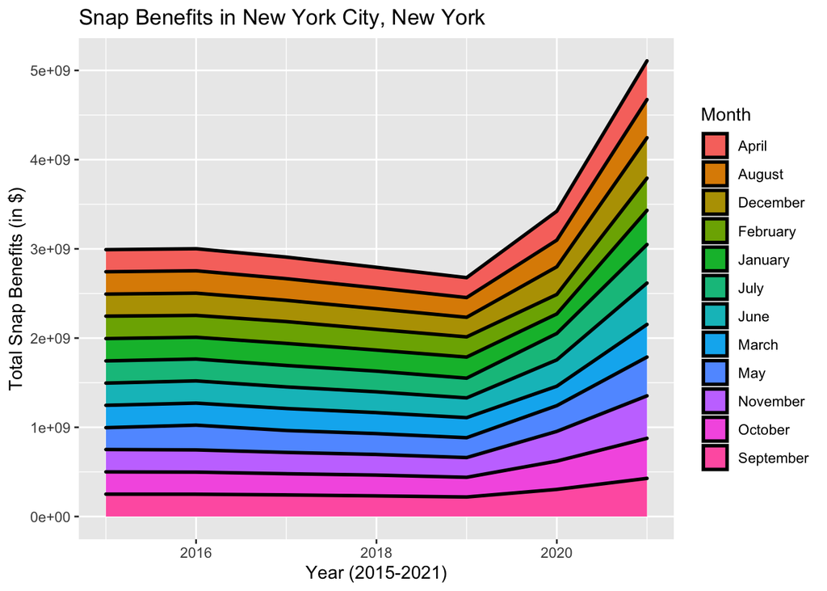

**What is the trend of SNAP-receiving households over time?**

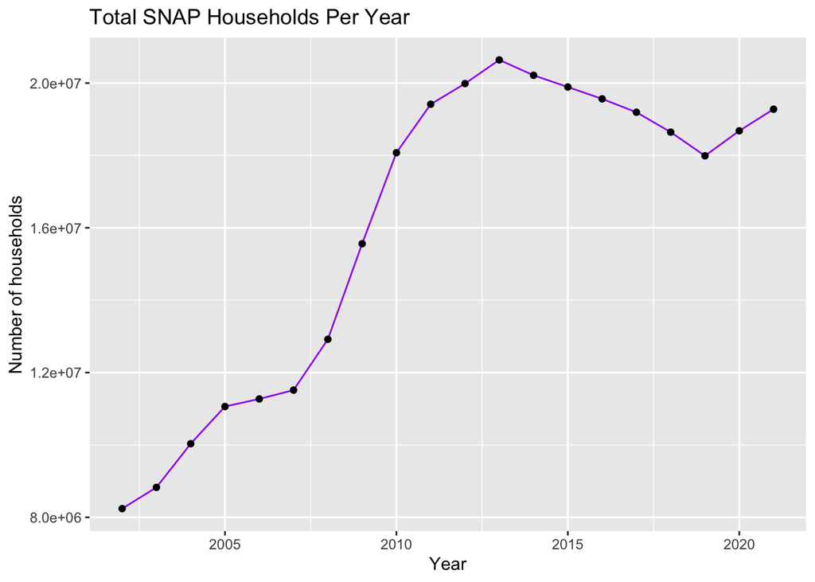

### **Expected Implications**:

Given that our Research questions are answered, we would be able to see when the highest amount of SNAP assistance is given out to families. An expected implication of answering this question can include better preparation of government resources for the SNAP program when it is at its busiest. Essentially, knowing when the program is the busiest can help governmental planners in ensuring the program is well staffed. Understanding how the count of SNAP receiving individuals, either by the New York district or as the whole state, changes over time can be an indication of the SNAP program’s use over time. If it’s found that SNAP program individuals are dropping throughout time, government planners may be able to downsize the program to allocate resources in a different area without compromising the effectiveness of the program. Overall, the answers to our questions can help policy makers make better informed decisions regarding the SNAP program, hopefully improving its effectiveness.

### **Limitations**:

For one, we are always limited by our particular dataset. Given that our dataset focuses on the State of New York, it will be difficult to answer broader questions relating to the SNAP program across the nation. This can be potentially addressed though applying the data to similar metropolitan areas with similar levels of SNAP receiving individuals, though in reality every state is most likely different in these variables. The dataset additionally does not provide information regarding which specific foods the SNAP program helps provide. insight on the food types bought by the individuals receiving SNAP assistance therefore will not be possible to find. This may be addressed through finding surveys which include data on the foods bought with SNAP funds, but this type of data may prove difficult to find.

### **References**:

> New York State Office of Temporary and Disability Assistance. (2022, January 31). Supplemental Nutrition Assistance Program (SNAP) caseloads and expenditures: Beginning 2002: State of New York. Supplemental Nutrition Assistance Program (SNAP) Caseloads and Expenditures: Beginning 2002 | State of New York. Retrieved February 5, 2022, from https://data.ny.gov/Human-Services/Supplemental-Nutrition-Assistance-Program-SNAP-Cas/dq6j-8u8z

> Silva, Christianna. 'Food Insecurity in the U.S. by the Numbers.' NPR, NPR, 27 Sept. 2020, https://www.npr.org/2020/09/27/912486921/food-insecurity-in-the-u-s-by-the-numbers.

> 'The State of Food Security and Nutrition in the World 2021.' Www.fao.org, 2021, https://www.fao.org/state-of-food-security-nutrition

> Keith-Jennings , Brynne. 'Raising SNAP Benefits Would Have Powerful Effects on Food Security, Poverty, Health.' Center on Budget and Policy Priorities, 12 Aug. 2019, https://www.cbpp.org/blog/raising-snap-benefits-would-have-powerful-effects-on-food-security-poverty-health